# Root Finding

Yuji Saikai ysaikai@unimelb.edu.au School of Mathematics and Statistics The University of Melbourne

8 March 2021

These notes are based on Chapter 10 of Jones, O., Maillardet, R., & Robinson, A. (2009). *Introduction to scientific programming and simulation using R*. CRC Press.

# Introduction

A **root** is a solution of $f(x)=0$. Visually, a root is a point where the graph $y=f(x)$ crosses the x-axis. For example, in the interval $[0,10]$, there are two roots of the following $f$:

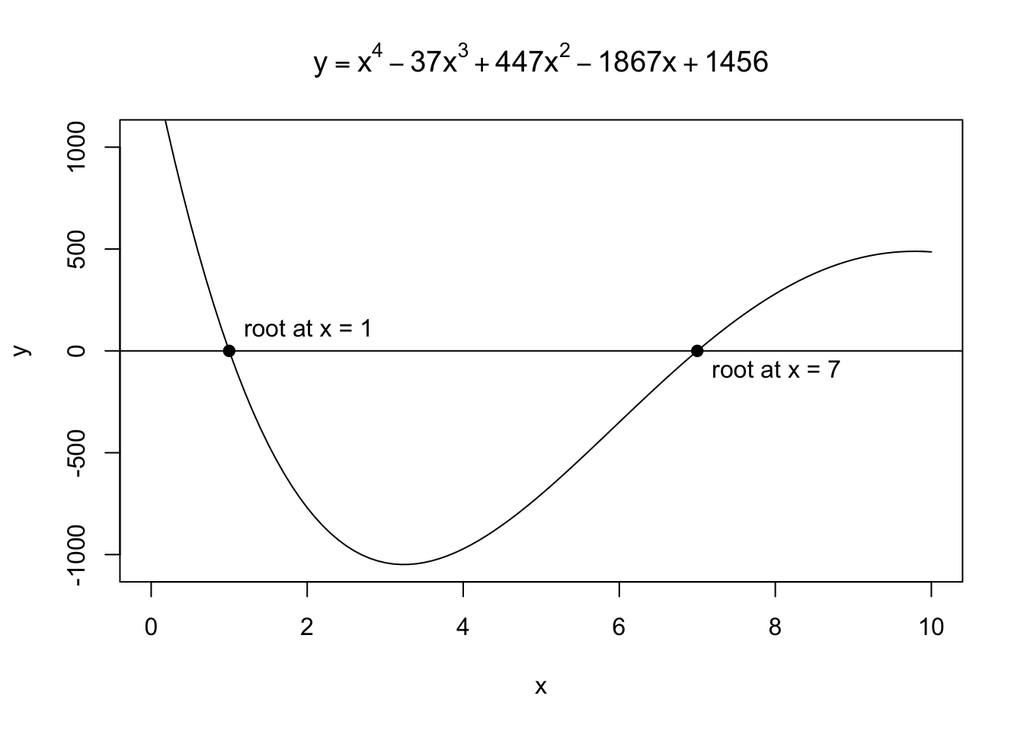

```r
plot(c(1,7), c(0,0), pch = 19,
     xlim=c(0,10), ylim=c(-1050,1050),
     xlab="x", ylab="y",
     main=expression(y==x^4-37*x^3+447*x^2-1867*x+1456))
curve((x-1)*(x-7)*(x-13)*(x-16), from=0, to=10, add=TRUE)
abline(h=0)
text(1, 100, "root at x = 1", pos=4)
text(7, -100, "root at x = 7", pos=4)
```

Root finding is important because:

- Factorisation of a polynomial, one of the most popular classes of functions (e.g., Taylor series approximation). For example,
  $$\begin{align}
  f(x) &= x^4-37x^3+447x^2-1867x+1456\\
  &= (x-1)(x-7)(x-13)(x-16)
  \end{align}$$
- Many problems can be modelled as root finding of suitable functions. Remember that finding a root of $f(x)$ is equivalent to solving an equation $g(x)=h(x)$ where $f(x) = g(x)-h(x)$.

## Loan repayments

Let’s suppose:

- $P_n$ : Remaining amount of loan after $n$ months
- $P_0$ : Initial amount of loan
- $N$ : Duration of repayments
- $A$ : Monthly repayment amount
- $r$ : Monthly interest rate

Given $P_{n-1}$, we know:
$$P_n = (1+r)P_{n-1} - A$$
That is, each month, interest based on $P_{n-1}$ is added and then you repay $A$. The solution of the difference equation (i.e., the expression of $P_n$ as a function of $n$) is:

$$P_n = (1+r)^nP_0 - \frac{A}{r}\left((1+r)^n-1\right) .$$

> To see this, for each $k\in\{1,\dots,n\}$, multiply both sides of $P_k = (1+r)P_{k-1} - A$ by $(1+r)^{n-k}$ and get a telescoping sum.

We negotiate with a bank on the interest rate. A question is under what $r$, can we repay the loan after $N$ months?

We could get the answer by solving $P_N=0$ for $r$:
$$\begin{alignat}{2}
&& P_N &= 0\\
&\Leftrightarrow \quad & (1+r)^NP &= \frac{A}{r}\left((1+r)^N-1\right)\\
&\Leftrightarrow \quad & (1+r)^N &= \frac{A}{A-rP}\\
&&&\vdots
\end{alignat}$$
Well, this is hard (at least for me). Instead, we may use numerical root-finding methods for $f(r):=P_N$.

# Fixed-point iteration

## Fixed point

Let $g: \mathbb{R}\to\mathbb{R}$ be a continuous function. Then, a **fixed point** of $g$ is a solution of $g(x)=x$. Visually, a fixed point is a point where the graph $y=g(x)$ crosses the 45-degree line. For example, a hyperbolic tangent
$$g(x) = 2\tanh(x) = 2\frac{e^{x}-e^{-x}}{e^{x}+e^{-x}}$$
has three fixed points: $x = -1.915, 0, 1.915$.

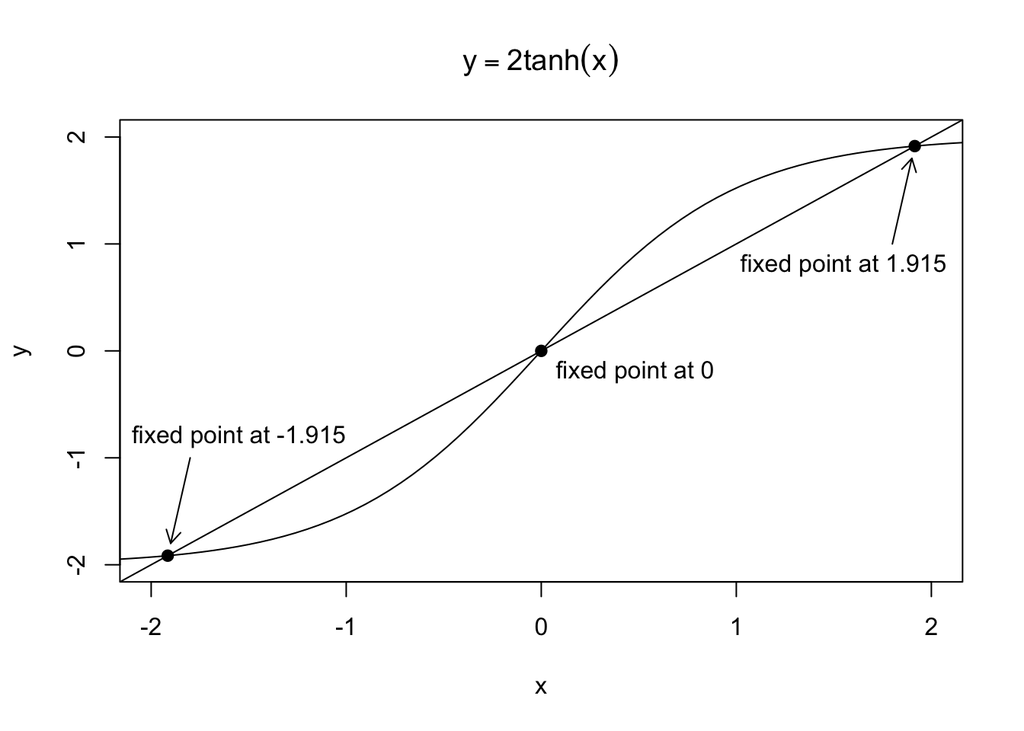

```r
x <- c(-1.915,0,1.915)
y <- c(-1.915,0,1.915)
plot(x, y, pch = 19, xlim=c(-2,2), ylim=c(-2,2))
title(expression(y==2*tanh(x)))
curve(2*tanh(x), from=-3, to=3, add=TRUE)
curve(x*1, from=-3, to=3, add=TRUE)
text(-1.55, -.8, "fixed point at -1.915")
text(0, -.2, "fixed point at 0", pos=4)
text(1.55, .8, "fixed point at 1.915")
arrows(-1.8, -1, -1.9, -1.8, length=0.1)
arrows(1.8, 1, 1.9, 1.8, length=0.1)
```

Given $f$, root finding is to compute a value $a$ such that $f(a)=0$. But, as long as we legally manipulate the equation $f(a)=0$, the same $a$ satisfies both the original $f(a)=0$ and transformed equations.

This is why we may turn root finding into a fixed-point problem. Among many possible ways to manipulate $f(a)=0$, the following is perhaps the simplest.
$$f(a)=0 \;\Leftrightarrow\; f(a)+a=a$$
Then, we define a new function $g$ such that $g(x):=f(x)+x$ and try to find a fixed point of $g$ to find a root of $f$.

Clearly, this is not the only way of transformation and, as seen below, the performance of fixed-point iteration depends on how we transform $f(a)=0$ and define $g$.

## Method

The **fixed-point iteration** is a method for solving $g(x)=x$ by iteratively generating points $x_0,x_1,\dots$ that, we hope, converge to $a$ such that $g(a)=a$.

Given $x_n$, the generation of points follows a simple difference equation $x_{n+1}=g(x_n)$. Clearly, to start somewhere at $n=0$, we need an initial guess $x_0$.

If a sequence $\{x_n\}$ converges to some point $a$, then the continuity of $g$ implies that $a$ is indeed a fixed point of $g$.

$$a = \lim_{n\to\infty}x_{n+1}
= \lim_{n\to\infty}g(x_n)
= g\left(\lim_{n\to\infty}x_n\right)
= g(a)$$

An issue of fixed-point iteration is that **convergence of $\{x_n\}$ is not guaranteed but depends on $g$ and $x_0$**.

For example, in the case of $g(x)=2\tanh(x)$, $\{x_n\}$ converges no matter what $x_0$ is.

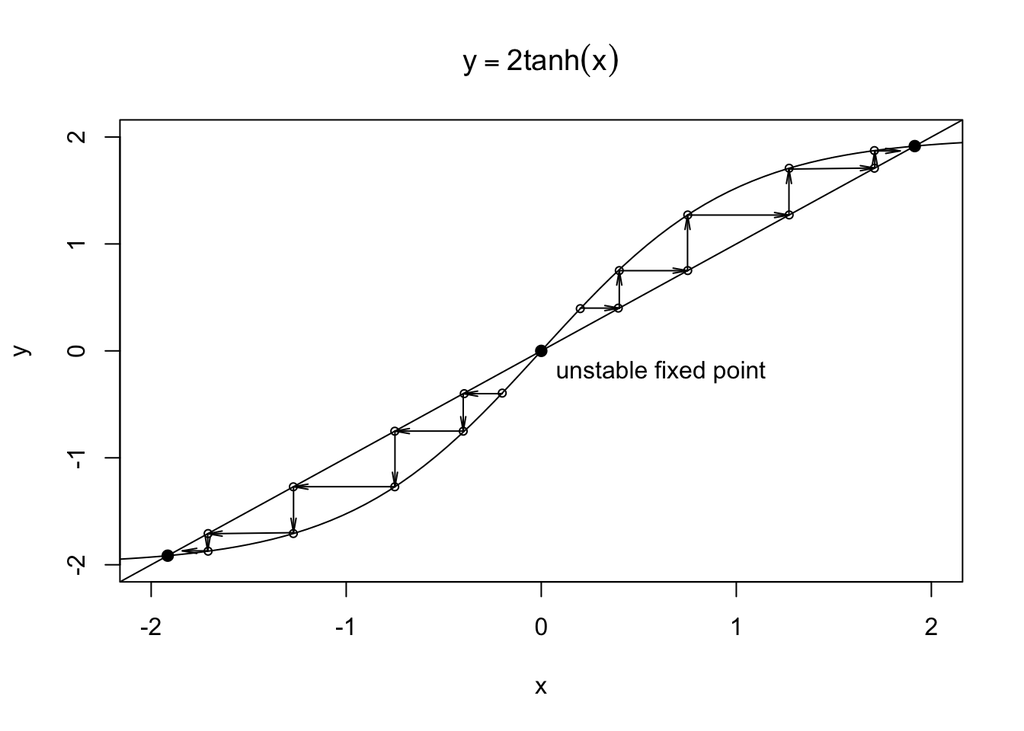

```r
x <- c(.2,0.395,0.4,0.751,0.751,1.271,1.271,1.708,1.708,
       -.2,-0.395,-0.4,-0.751,-0.751,-1.271,-1.271,-1.708,-1.708)
y <- c(0.395,0.4,0.751,0.751,1.271,1.271,1.708,1.708,1.873,
       -0.395,-0.4,-0.751,-0.751,-1.271,-1.271,-1.708,-1.708,-1.873)
plot(x, y, xlim=c(-2,2), ylim=c(-2,2), cex=.7)
points(c(-1.915,0,1.915), c(-1.915,0,1.915), pch = 19)
text(0, -.2, "unstable fixed point", pos=4)
title(expression(y==2*tanh(x)))
curve(2*tanh(x), from=-3, to=3, add=TRUE)
curve(x*1, from=-3, to=3, add=TRUE)
arrows(.2, .4, .4, .4, length=0.1, angle=10)
arrows(.4, .4, .4, .75, length=0.1, angle=10)
arrows(.4, .75, .75, .75, length=0.1, angle=10)
arrows(.75, .75, .75, 1.27, length=0.1, angle=10)
arrows(.75, 1.27, 1.27, 1.27, length=0.1, angle=10)
arrows(1.27, 1.27, 1.27, 1.7, length=0.1, angle=10)
arrows(1.27, 1.7, 1.71, 1.71, length=0.1, angle=10)
arrows(1.71, 1.71, 1.71, 1.87, length=0.1, angle=10)
arrows(1.71, 1.87, 1.84, 1.87, length=0.1, angle=10)
arrows(-.2, -.4, -.4, -.4, length=0.1, angle=10)
arrows(-.4, -.4, -.4, -.75, length=0.1, angle=10)
arrows(-.4, -.75, -.75, -.75, length=0.1, angle=10)
arrows(-.75, -.75, -.75, -1.27, length=0.1, angle=10)
arrows(-.75, -1.27, -1.27, -1.27, length=0.1, angle=10)
arrows(-1.27, -1.27, -1.27, -1.7, length=0.1, angle=10)
arrows(-1.27, -1.7, -1.71, -1.71, length=0.1, angle=10)
arrows(-1.71, -1.71, -1.71, -1.87, length=0.1, angle=10)
arrows(-1.71, -1.87, -1.84, -1.87, length=0.1, angle=10)
```

> Can you follow how arrows move? Basically, a point on the graph $y=g(x)$ moves horizontally to the 45-degree line because the current $y$ value, say $y=g(x_n)$, becomes a new $x=x_{n+1}$ value. Then, it moves vertically to the graph and gets a new $y=g(x_{n+1})$ value.

In contrast, in the case of $g(x)=e^x-1$, $\{x_n\}$ converges if $x_0\leq0$ and diverges if $x_0>0$.

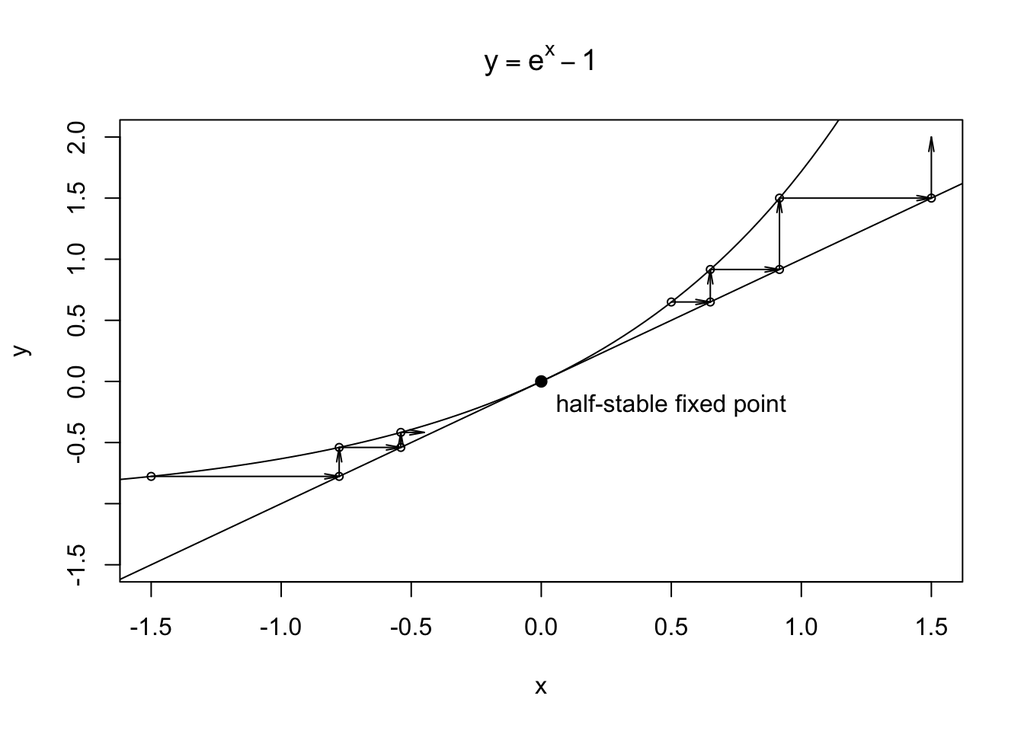

```r
x <- c(.5,0.65,0.65,0.916,0.916,1.5,
       -1.5,-0.777,-0.777,-0.54,-0.54)
y <- c(0.65,0.65,0.916,0.916,1.5,1.5,
       -0.777,-0.777,-0.54,-0.54,-0.417)
plot(x, y, xlim=c(-1.5,1.5), ylim=c(-1.5,2), cex=.7)
points(0, 0, pch = 19)
text(0, -.2, "half-stable fixed point", pos=4)
title(expression(y==e^x-1))
curve(exp(x)-1, from=-2, to=2, add=TRUE)
curve(x*1, from=-2, to=2, add=TRUE)
arrows(.5, .65, .65, .65, length=0.1, angle=10)
arrows(.65, .65, .65, .916, length=0.1, angle=10)
arrows(.65, .916, .916, .916, length=0.1, angle=10)
arrows(.916, .916, .916, 1.5, length=0.1, angle=10)
arrows(.916, 1.5, 1.5, 1.5, length=0.1, angle=10)
arrows(1.5, 1.5, 1.5, 2, length=0.1, angle=10)
arrows(-1.5, -0.777, -.777, -0.777, length=0.1, angle=10)
arrows(-0.777, -0.777, -.777, -0.54, length=0.1, angle=10)
arrows(-0.777, -0.54, -0.54, -0.54, length=0.1, angle=10)
arrows(-0.54, -0.54, -0.54, -0.417, length=0.1, angle=10)
arrows(-0.54, -0.417, -0.45, -0.417, length=0.1, angle=10)
```

In general, a fixed point $a$ is stable if $|g'(a)|<1$ and unstable if $|g'(a)|>1$.

Visually, assuming $g'(a)>0$, $a$ is stable if the graph of $g$ crosses the 45-degree line **from above** and unstable if crossing **from below**.

Now suppose $\{x_n\}$ converges to $a$, which is usually reached only in the limit $(n\to\infty)$. In practice, we cannot iterate forever and must stop at some point. So, we commonly use the following stopping criteria:

- $|x_n-x_{n-1}|\leq\epsilon$, where $\epsilon$ is a small positive number
- $n=max.iter$, where $max.iter$ is the maximum number of iterations allowed

Here is an implementation of the algorithm.

```r
fixedpoint <- function(f, x0, tol=1e-9, max.iter=100) {
  xold <- x0
  xnew <- f(xold)
  iter <- 1

  while ((abs(xnew-xold) > tol) && (iter < max.iter)) {
    xold <- xnew
    xnew <- f(xold)
    iter <- iter + 1
  }

  if (abs(xnew-xold) > tol) {
    print("Failed to converge.")
    return(NULL)
  } else {
    print("Converged")
    print(paste("a =", xnew, "| iter =", iter))
    return(xnew)
  }
}
```

## Root of $\log(x)-\exp(-x)$

First, let’s draw $y=\log(x)-\exp(-x)$. It seems the root sits between 1.0 and 1.5.

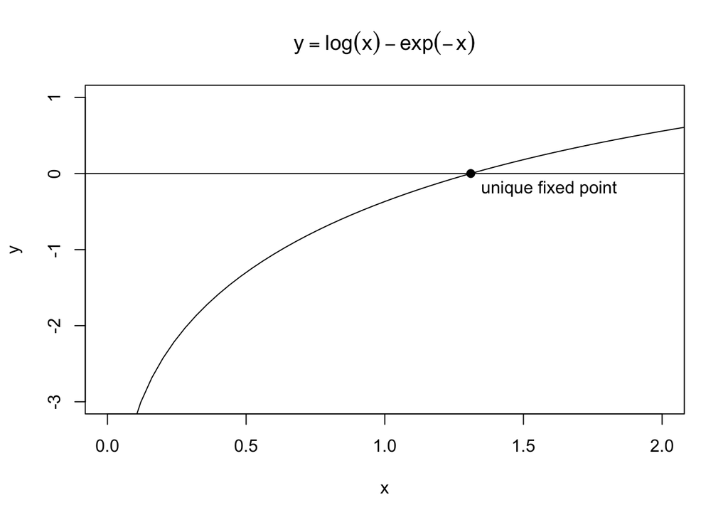

```r
x <- c(1.31)
y <- c(0)
plot(x, y, pch = 19, xlim=c(0,2), ylim=c(-3,1))
text(x, -.2, "unique fixed point", pos=4)
title(expression(y==log(x)-exp(-x)))
curve(log(x)-exp(-x), xlab="x", ylab="y", from=0, to=4, add=TRUE)
abline(h=0)
```

As mentioned above, there are many ways to manipulate $f(x)=0$ and define the corresponding $g$. In this example, we examine three different transformations:

$$\begin{align}
g_1(x) &= \exp(\exp(-x))\\
g_2(x) &= x-\log{x}+\exp(-x)\\
g_3(x) &= x+\log{x}-\exp(-x)
\end{align}$$

```r
g1 <- function(x) exp(exp(-x))
a1 <- fixedpoint(g1, 1.5)
```

```
## [1] "Converged"
## [1] "a = 1.30979958596558 | iter = 20"
```

```r
g2 <- function(x) x - log(x) + exp(-x)
a2 <- fixedpoint(g2, 1.5)
```

```
## [1] "Converged"
## [1] "a = 1.30979958581392 | iter = 7"
```

```r
g3 <- function(x) x + log(x) - exp(-x)
a3 <- fixedpoint(g3, 1.5)
```

```
## [1] "Failed to converge."
```

Both $g_1$ and $g_2$ find the fixed point of 1.3098, but $g_3$ failed. Also, note that the search is faster for $g_2$ than for $g_1$.

The results illustrate that the fixed-point iteration has some disadvantage. We need to transform $f(x)=0$ into suitable $g(x)=x$, and some forms of $g$ perform much better than others. This is inconvenient. In our example, while $g_3$ is in a sense the most “natural” form satisfying $f(x)=g(x)-x$, it has the worst performance. In stark contrast, $g_2$ obtained simply from $-f(x)=0$ has the best performance.

# Newton-Raphson method

The Newton-Raphson method uses linear approximation of $f(x)$ to generate a sequence of guesses at a root $(a)$.

Remember that linear approximation (i.e., the 1st-order Taylor approximation) of $f(x)$ at $x_n$ is
$$f(x) \approx f(x_n)+f'(x_n)(x-x_n) .$$
Thanks to the linearity, it is easy to find a root $(\hat{a})$ of the approximated function:
$$\begin{align}
& f(x_n)+f'(x_n)(\hat{a}-x_n) = 0\\
\Leftrightarrow\quad & \hat{a} = x_n - \frac{f(x_n)}{f'(x_n)}
\end{align}$$

Now, suppose that $x_n$ is the current guess at $a$. Then, given the approximated function, it is natural to see the estimated root $(\hat{a})$ as an improved guess. This is the idea behind the Newton-Raphson method:
$$x_{n+1} = x_n - \frac{f(x_n)}{f'(x_n)} .$$

Similar to the fixed-point iteration, we cannot guarantee convergence of the Newton-Raphson method. But, If a sequence $\{x_n\}$ converges to some point $a$, then $a$ is indeed a root of $f$ under some conditions.

Specifically, suppose that $f$ is continuously differentiable, and that $f'$ is bounded. Then,
$$\begin{align}
a &= \lim_{n\to\infty}x_{n+1}\\
&= \lim_{n\to\infty} \left( x_n - \frac{f(x_n)}{f'(x_n)} \right)\\
&= \lim_{n\to\infty}x_{n} - \frac{f(\lim_{n\to\infty}x_{n})}{f'(\lim_{n\to\infty}x_{n})}\\
&= a - \frac{f(a)}{f'(a)} ,
\end{align}$$
which implies $f(a)=0$ because $|f'(a)|$ is finite.

There are also similar stopping criteria:

- $|f(x_n)|\leq\epsilon$, where $\epsilon$ is a small positive number
- $n=max.iter$, where $max.iter$ is the maximum number of iterations allowed

> Can you see why the first criterion makes sense?

Here is an implementation of the algorithm.

```r
# fg for a vector of function & gradient
newtonraphson <- function(fg, x0, tol=1e-9, max.iter=100) {
  x <- x0
  fg.x <- fg(x) # fg.x for fg evaluated at x
  iter <-  0

  while ((abs(fg.x[1]) > tol) && (iter < max.iter)) {
    x <- x - fg.x[1]/fg.x[2]
    fg.x <- fg(x)
    iter <- iter + 1
  }

  if (abs(fg.x[1]) > tol) {
    print("Failed to converge.")
    return(NULL)
  } else {
    print("Converged")
    print(paste("a =", x, "| iter =", iter))
    return(x)
  }
}
```

## Root of $\log(x)-\exp(-x)$

Let’s apply the Newton-Raphson method to the same $f(x)=\log(x)-\exp(-x)$.

A result looks like this.

```r
fg <- function(x){
  f <- log(x) - exp(-x)
  grad <- 1/x + exp(-x)
  return(c(f, grad))
}
a <- newtonraphson(fg, 1.5)
```

```
## [1] "Converged"
## [1] "a = 1.30979958580415 | iter = 4"
```

> Note that `fg` needs to return both a faction value and derivative at $x$

As you can see, it finds the same root $(= 1.3098)$ with fewer iterations than the fixed-point iteration. The better performance is mainly because the Newton-Raphson method makes use of the extra information, namely the derivative.

Considering the task of root finding, i.e., search for a point where $f(x)$ crosses the x-axis, knowing $f'(x)$ is quite useful because it tells the direction in which $f(x)$ increases. Intuitively, if we currently have $f(x_n)>0$, we want to follow the opposite direction of $f'(x)$ to get closer to a root.

# Secant method

A motivation for the secant method is “What if we do not have access to the derivative?” It happens because the derivative can be very expensive to compute or even does not exist at all. Using the secant method, we can use the same idea of linear approximation of $f(x)$ without the derivative.

As the name suggests, the method substitutes the slope of secant line for the derivative.

Suppose that $x_{n-1}$ and $x_n$ are the current guesses at a root. Then, an estimate of $f'(x_n)$ is $\frac{f(x_n)-f(x_{n-1})}{x_n-x_{n-1}}$. Now, we can simply substitute this for the derivative used in the Newton-Raphson method to get the secant method.
$$\begin{align}
x_{n+1} &= x_n - \frac{f(x_n)}{\frac{f(x_n)-f(x_{n-1})}{x_n-x_{n-1}}}\\
&= x_n - f(x_n)\frac{x_n-x_{n-1}}{f(x_n)-f(x_{n-1})}
\end{align}$$

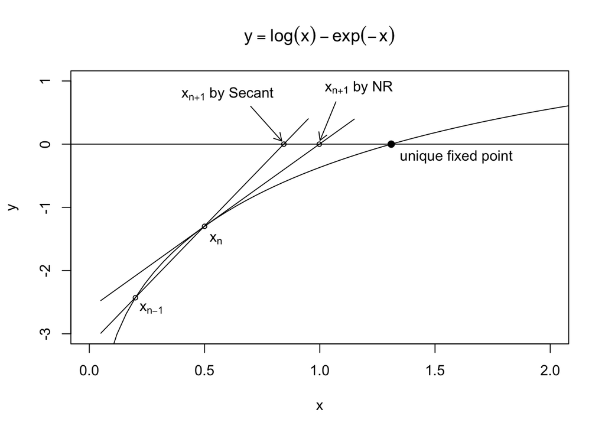

```r
x <- c(1.31)
y <- c(0)
plot(x, y, pch = 19, xlim=c(0,2), ylim=c(-3,1))
text(x, -.2, "unique fixed point", pos=4)
title(expression(y==log(x)-exp(-x)))
curve(log(x)-exp(-x), xlab="x", ylab="y", from=0, to=4, add=TRUE)
abline(h=0)
points(c(.5,.2,0.998,0.844), c(-1.3,-2.43,0,0), cex=.7)
curve(2.61*x-2.605, from=.05, to=1.15, add=TRUE)
curve(3.77*x-3.18, from=.05, to=.95, add=TRUE)
text(.55, -1.5, expression(x[n]))
text(.27, -2.6, expression(x[n-1]))
arrows(.7, .6, 0.835, .05, length=0.1)
arrows(1.07, .67, 1.001, .06, length=0.1)
text(.6, .8, expression(paste(x[n+1]," by Secant")))
text(1.17, .9, expression(paste(x[n+1]," by NR")))
```

Due to the estimated derivative information, as expected, the secant method does not perform as well as the Newton-Raphson method. But, this is often a reasonable trade-off in practice.

# Bisection method

While convergence is not guaranteed in none of the above methods, for the price of more iterations, it is guaranteed in the bisection method.

The bisection method belongs to a class of root-finding algorithms called **bracketing**, which successively isolates smaller intervals (brackets) that contain a root. In the bisection method, a bracket is always halved at each iteration.

First, find an interval $(x_l,x_r)$ such that $f(x_l)f(x_r)<0$, i.e., the graph $y=f(x)$ crosses the x-axis at least once in the interval. Then, repeat the following.

1. Halt and return either $x_l$ or $x_r$ if $x_r-x_l\leq\epsilon$.
2. Set $x_m = (x_l+x_r)/2$.
3. Halt and return $x_m$ if $f(x_m)=0$.
4. Set $x_r=x_m$ if $f(x_l)f(x_m)<0$. Otherwise, set $x_l=x_m$.

Here is an implementation of the algorithm.

```r
bisection <- function(f, x.l, x.r, tol=1e-9) {
  # Exception
  if (x.l >= x.r) {
    print("error: x.l >= x.r")
    return(NULL)
  }

  f.l <- f(x.l)
  f.r <- f(x.r)

  # Exception
  if (f.l*f.r > 0) {
    print("error: f(x.l)*f(x.r) > 0")
    return(NULL)
  } else if (abs(f.l) < tol) {
    return(x.l)
  } else if (abs(f.r) < tol) {
    return(x.r)
  }

  # Beginning of the main part
  iter <- 0
  while ((x.r - x.l) > tol) {
    x.m <- (x.l + x.r)/2
    f.m <- f(x.m)
    if (f.m == 0) {
      return(x.m)
    } else if (f.l*f.m < 0) {
      x.r <- x.m
      f.r <- f.m
    } else {
      x.l <- x.m
      f.l <- f.m
    }
    iter <- iter + 1
  }

  x.m <- (x.l + x.r)/2
  print(paste("a =", x.m, "| iter =", iter))
  return(x.m)
}
```

Let’s apply the bisection method to the same function $f(x)=\log(x)-\exp(-x)$. In contrast to an initial point to `fixedpoint` and `newtonraphson`, in this case, we supply to `bisection` two boundary points of an initial interval ($x_l$ and $x_r$).

```r
f <- function(x) log(x) - exp(-x)
a <- bisection(f, 1, 2)
```

```
## [1] "a = 1.30979958595708 | iter = 30"
```

As you will see, it finds the same root $(= 1.3098)$ using more iterations than the Newton-Raphson method.